# Trabajo 1 Multivariado

# Anchura de las caderas

## identificación de NaN

```r
knitr::kable(table(is.na(datosf[,5])), format = "markdown", caption = "Conteo NAs  Anchura de las caderas")
```

Conteo NAs Anchura de las caderas

| Var1 | Freq |
| --- | --- |
| FALSE | 200 |

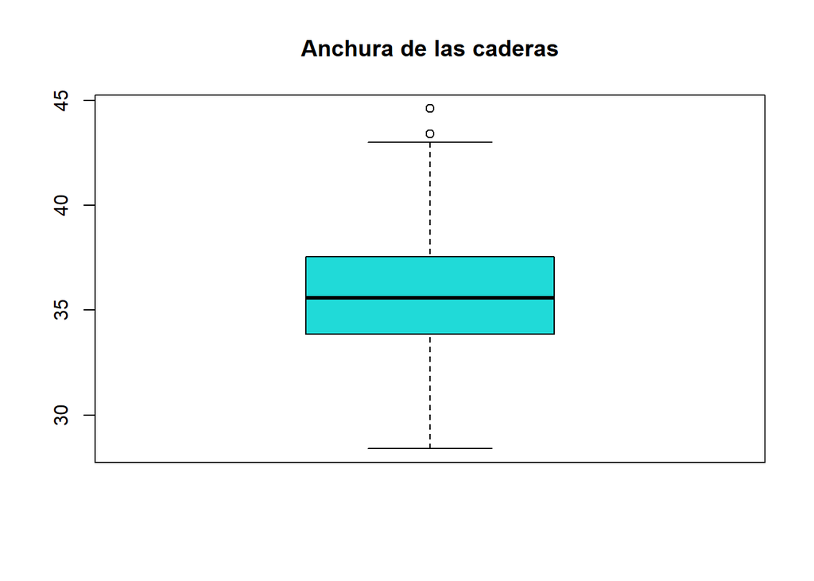

```r
v5 <- boxplot(datosf[,5], col = colores[1], horizontal = F, main = "Anchura de las caderas")
```

```r
aa1 <- data.frame(v5$out)
colnames(aa1)= "Atipicos"
aa1
```

```
##   Atipicos
## 1     43.4
## 2     44.6
```

## identificacion del dato atipico

```r
# Usando la función which() junto con la indexación de filas
fila_con_valor1 <- datosf[which(datosf$`Anchcaderas(cm)` == c(43.4,44.6)), ]

# fila_con_valor contendrá la fila que contiene el valor buscado
print(fila_con_valor1)
```

```
##   Sexo Masa(kg) Permuslo(cm) Perabdo(cm) Anchcaderas(cm) Longpies(cm)
## 1  Muj     89.7         67.6        96.6            43.4         24.2
## 8  Muj     86.1           NA        93.4            44.6         24.2
##   Longman(cm) Estatura(cm) Cat_imc
## 1        18.7        167.3   OBESO
## 8        17.8        169.6   OBESO
```

En el gráfico se pueden observar datos que podrían considerarse atípicos, por lo que es necesario verificar si realmente cumplen con esta clasificación. En cuanto a la presencia de valores NaN, no encontramos ninguno en la variable. Además, respecto a los datos atípicos, se identificaron dos, pero es importante destacar que después de un análisis más detenido, concluimos que estos datos no pueden ser considerados atípicos. Todas las variables en estos registros son muy similares y concuerdan con las características esperadas en la realidad.